# Git Practice with RStudio

Thomas Kane

11/6/2019

```r
knitr::opts_chunk$set(echo = TRUE)

library(tidyverse)
library(nycflights13)
library(lubridate)
library(Lock5Data)

chicago <- readRDS("chicago.rds")
heroes <- read_csv("heroes.csv")
powers <- read_csv("powers.csv")
```

## Introduction

As a group, pick one or two of the following questions to explore. Each question has at leat 2 sub-questions.

After you answer each sub-question, save and commit your changes (I recommend knitting at this point to make sure your code runs). At the end of each larger question, push your changes to GitHub and verify that your project on GitHub updated.

You do not need to correctly solve every part of the question; the goal is to practice workflow with RStudio + GitHub.

## Questions

### III. Data Visualization Exercise

Let’s make maps using ggplot and the `HappyPlanetIndex` data.

#### Question 1

1. See if you can adapt the textbook code for the map of New Zealand in section 3.9 to display a map of the world instead. Color the continents forest green with a lemon chiffon outline. Check out [this overview](http://www.stat.columbia.edu/~tzheng/files/Rcolor.pdf) of colors in R if you want to play with the coloring a bit.

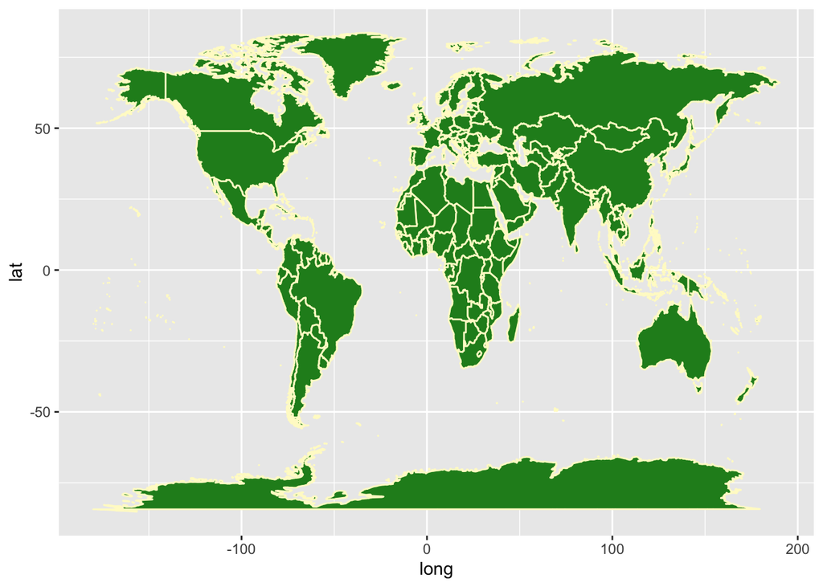

```r
world <- map_data("world")
ggplot(world, aes(long, lat, group = group)) +
  geom_polygon(fill = "forestgreen", colour = "lemonchiffon")
```

#### Question 2

2. Create a choropleth map of world happiness using `HappyPlanetIndex` data. In other words, create a world map, but instead of having every country the same color, apply different colors based on the happiness level of that country (using the Happiness variable in the HappyPlanetIndex data set). [This guide](https://www.datanovia.com/en/blog/how-to-create-a-map-using-ggplot2/) can get you started.

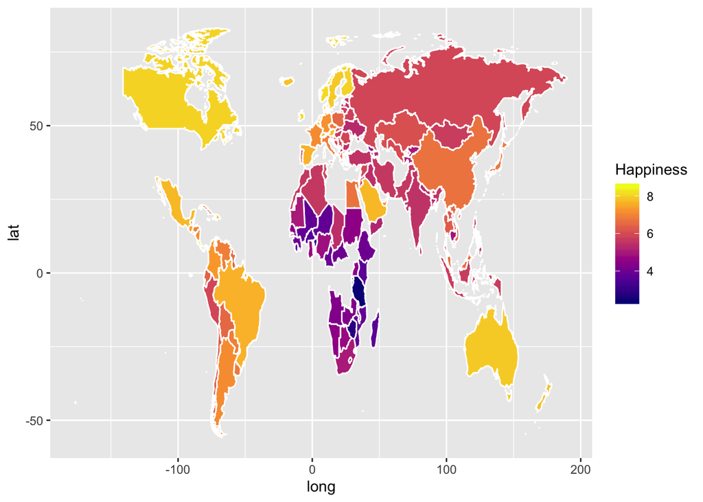

```r
world <- map_data("world")

world_map <- world %>%
  mutate(
    world = ifelse(region == "USA", "United States of America", region)
  )

hap.lvl.map <- left_join(HappyPlanetIndex, world_map, by = c("Country" = "region"))

ggplot(hap.lvl.map, aes(long, lat, group = group))+
  geom_polygon(aes(fill = Happiness), color = "white")+
  scale_fill_viridis_c(option = "C")
```

### IV. Opt. Discussion Exercises

Discussion exercises that should be done with the class.

#### All about NA

Play around with NA values. What happens if you find the mean of a variable that has missing data? How can you avoid this? Discuss the pros and cons of each approach, and why you think R takes the default setting that it does.

Then dig deeper: Try to predict the results of each of the following pieces of code, and discuss whether the results make sense based on your previous thoughts about NA’s.

```r
NA^0

NA | TRUE

NA & FALSE

NA | FALSE

NA * 0

NA == NA

NA^FALSE | NA^TRUE

NA^FALSE & NA^TRUE
```

#### Filter vs [ ]

We learned in week 1 and 2 to subset a vector or data frame using [ ]. This is very similar to filter, but the syntax is different. For instance, to select the flights which traveled the maximum distance, we could use:

```r
maxdist <- max(flights$distance, na.rm = TRUE)

flights[flights$distance == maxdist,]
```

```
## # A tibble: 342 x 19
##     year month   day dep_time sched_dep_time dep_delay arr_time
##    <int> <int> <int>    <int>          <int>     <dbl>    <int>
##  1  2013     1     1      857            900        -3     1516
##  2  2013     1     2      909            900         9     1525
##  3  2013     1     3      914            900        14     1504
##  4  2013     1     4      900            900         0     1516
##  5  2013     1     5      858            900        -2     1519
##  6  2013     1     6     1019            900        79     1558
##  7  2013     1     7     1042            900       102     1620
##  8  2013     1     8      901            900         1     1504
##  9  2013     1     9      641            900      1301     1242
## 10  2013     1    10      859            900        -1     1449
## # … with 332 more rows, and 12 more variables: sched_arr_time <int>,
## #   arr_delay <dbl>, carrier <chr>, flight <int>, tailnum <chr>,
## #   origin <chr>, dest <chr>, air_time <dbl>, distance <dbl>, hour <dbl>,
## #   minute <dbl>, time_hour <dttm>
```

Compare this approach to using filter. Which do you like better? Which is clearer? Consider also the following example, which may be relevant:

(You may need to change the name of the temperature varaible below if you already completed BE3.)

```r
maxtemp <- max(chicago$tmpd, na.rm = TRUE)

chicago[chicago$tmpd == maxtemp,]
```

```
##      city tmpd   dptp       date pm25tmean2 pm10tmean2 o3tmean2 no2tmean2
## 3116 chic   92 76.375 1995-07-13         NA       92.5 58.54952  27.31775
## NA   <NA>   NA     NA       <NA>         NA         NA       NA        NA
```